# Risk Factor Analysis

## Outcome Variable

**Outcome Variable:** ever_wasted

## Predictor Variables

**Intervention Variable:** nhh

**Adjustment Set:**

- arm
- W_mage
- meducyrs
- feducyrs
- W_mhtcm
- W_mwtkg
- W_mbmi
- W_nrooms
- impfloor
- impsan
- safeh20
- delta_W_mage
- delta_meducyrs
- delta_feducyrs
- delta_W_mhtcm
- delta_W_mwtkg
- delta_W_mbmi
- delta_W_nrooms
- delta_impfloor
- delta_impsan
- delta_safeh20

## Stratifying Variables

The analysis was stratified on these variable(s):

- agecat
- studyid
- country

## Data Summary

| agecat | studyid | country | nhh | ever_wasted | n_cell | n |
| --- | --- | --- | --- | --- | --- | --- |
| 0-24 months | ki1000108-IRC | INDIA | 3 or less | 0 | 20 | 410 |
| 0-24 months | ki1000108-IRC | INDIA | 3 or less | 1 | 38 | 410 |
| 0-24 months | ki1000108-IRC | INDIA | 4-5 | 0 | 63 | 410 |
| 0-24 months | ki1000108-IRC | INDIA | 4-5 | 1 | 95 | 410 |
| 0-24 months | ki1000108-IRC | INDIA | 6-7 | 0 | 38 | 410 |
| 0-24 months | ki1000108-IRC | INDIA | 6-7 | 1 | 69 | 410 |
| 0-24 months | ki1000108-IRC | INDIA | 8+ | 0 | 20 | 410 |
| 0-24 months | ki1000108-IRC | INDIA | 8+ | 1 | 67 | 410 |
| 0-24 months | ki1000304b-SAS-FoodSuppl | INDIA | 3 or less | 0 | 24 | 418 |
| 0-24 months | ki1000304b-SAS-FoodSuppl | INDIA | 3 or less | 1 | 14 | 418 |
| 0-24 months | ki1000304b-SAS-FoodSuppl | INDIA | 4-5 | 0 | 95 | 418 |
| 0-24 months | ki1000304b-SAS-FoodSuppl | INDIA | 4-5 | 1 | 88 | 418 |
| 0-24 months | ki1000304b-SAS-FoodSuppl | INDIA | 6-7 | 0 | 66 | 418 |
| 0-24 months | ki1000304b-SAS-FoodSuppl | INDIA | 6-7 | 1 | 61 | 418 |
| 0-24 months | ki1000304b-SAS-FoodSuppl | INDIA | 8+ | 0 | 36 | 418 |
| 0-24 months | ki1000304b-SAS-FoodSuppl | INDIA | 8+ | 1 | 34 | 418 |
| 0-24 months | ki1017093-NIH-Birth | BANGLADESH | 3 or less | 0 | 58 | 624 |
| 0-24 months | ki1017093-NIH-Birth | BANGLADESH | 3 or less | 1 | 57 | 624 |
| 0-24 months | ki1017093-NIH-Birth | BANGLADESH | 4-5 | 0 | 134 | 624 |
| 0-24 months | ki1017093-NIH-Birth | BANGLADESH | 4-5 | 1 | 129 | 624 |
| 0-24 months | ki1017093-NIH-Birth | BANGLADESH | 6-7 | 0 | 72 | 624 |
| 0-24 months | ki1017093-NIH-Birth | BANGLADESH | 6-7 | 1 | 69 | 624 |
| 0-24 months | ki1017093-NIH-Birth | BANGLADESH | 8+ | 0 | 62 | 624 |
| 0-24 months | ki1017093-NIH-Birth | BANGLADESH | 8+ | 1 | 43 | 624 |
| 0-24 months | ki1017093b-PROVIDE | BANGLADESH | 3 or less | 0 | 98 | 700 |
| 0-24 months | ki1017093b-PROVIDE | BANGLADESH | 3 or less | 1 | 42 | 700 |
| 0-24 months | ki1017093b-PROVIDE | BANGLADESH | 4-5 | 0 | 211 | 700 |
| 0-24 months | ki1017093b-PROVIDE | BANGLADESH | 4-5 | 1 | 111 | 700 |
| 0-24 months | ki1017093b-PROVIDE | BANGLADESH | 6-7 | 0 | 94 | 700 |
| 0-24 months | ki1017093b-PROVIDE | BANGLADESH | 6-7 | 1 | 57 | 700 |

[output cut: 114 more lines]

The following strata were considered:

- agecat: 0-24 months, studyid: ki1000108-IRC, country: INDIA
- agecat: 0-24 months, studyid: ki1000304b-SAS-FoodSuppl, country: INDIA
- agecat: 0-24 months, studyid: ki1017093-NIH-Birth, country: BANGLADESH
- agecat: 0-24 months, studyid: ki1017093b-PROVIDE, country: BANGLADESH
- agecat: 0-24 months, studyid: ki1017093c-NIH-Crypto, country: BANGLADESH
- agecat: 0-24 months, studyid: ki1148112-LCNI-5, country: MALAWI
- agecat: 0-6 months, studyid: ki1000108-IRC, country: INDIA
- agecat: 0-6 months, studyid: ki1000304b-SAS-FoodSuppl, country: INDIA
- agecat: 0-6 months, studyid: ki1017093-NIH-Birth, country: BANGLADESH
- agecat: 0-6 months, studyid: ki1017093b-PROVIDE, country: BANGLADESH
- agecat: 0-6 months, studyid: ki1017093c-NIH-Crypto, country: BANGLADESH
- agecat: 0-6 months, studyid: ki1148112-LCNI-5, country: MALAWI
- agecat: 6-24 months, studyid: ki1000108-IRC, country: INDIA
- agecat: 6-24 months, studyid: ki1000304b-SAS-FoodSuppl, country: INDIA
- agecat: 6-24 months, studyid: ki1017093-NIH-Birth, country: BANGLADESH
- agecat: 6-24 months, studyid: ki1017093b-PROVIDE, country: BANGLADESH
- agecat: 6-24 months, studyid: ki1017093c-NIH-Crypto, country: BANGLADESH
- agecat: 6-24 months, studyid: ki1148112-LCNI-5, country: MALAWI

### Dropped Strata

Some strata were dropped due to rare outcomes:

- agecat: 0-6 months, studyid: ki1000304b-SAS-FoodSuppl, country: INDIA
- agecat: 0-6 months, studyid: ki1148112-LCNI-5, country: MALAWI

## Methods Detail

We’re interested in the causal parameters $E[Y_a]$ for all values of $a \in \mathcal{A}$. These parameters represent the mean outcome if, possibly contrary to fact, we intervened to set all units to have $A=a$. Under the randomization and positivity assumptions, these are identified by the statistical parameters $\psi_a=E_W[E_{Y|A,W}(Y|A=a,W)]$. In addition, we’re interested in the mean of $Y$, $E[Y]$ under no intervention (the observed mean). We will estimate these parameters by using SuperLearner to fit the relevant likelihood factors – $E_{Y|A,W}(Y|A=a,W)$ and $p(A=a|W)$, and then updating our likelihood fit using a joint TMLE.

For unadjusted analyses ($W=\{\}$), initial likelihoods were estimated using Lrnr_glm to estimate the simple $E(Y|A)$ and Lrnr_mean to estimate $p(A)$. For adjusted analyses, a small library containing Lrnr_glmnet, Lrnr_xgboost, and Lrnr_mean was used.

Having estimated these parameters, we will then use the delta method to estimate relative risks and attributable risks relative to a prespecified baseline level of $A$.

# Results Detail

## Results Plots

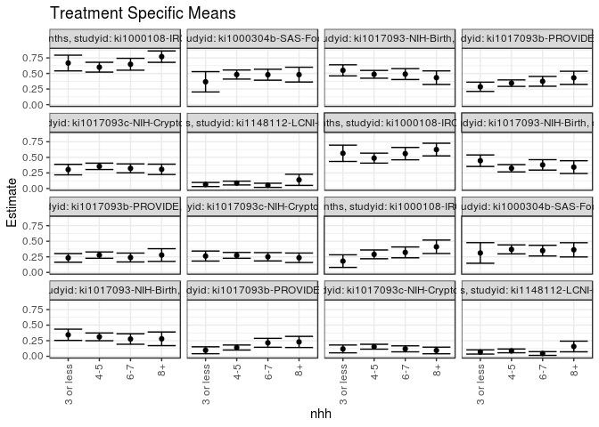

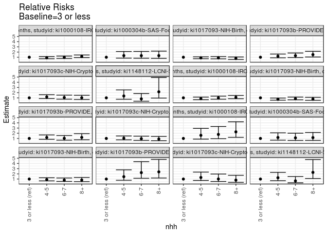

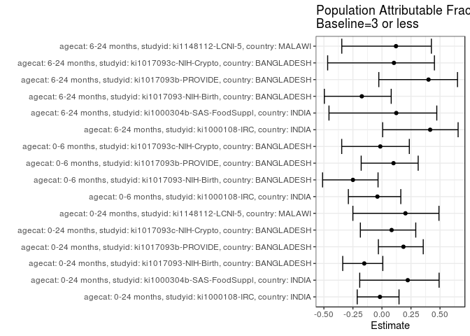

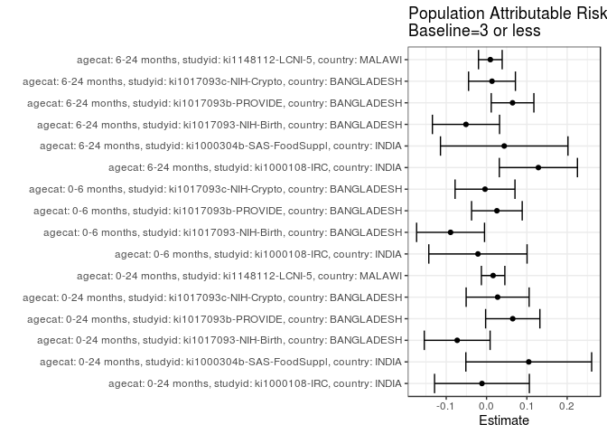

## Results Table

### Parameter: TSM

| agecat | studyid | country | intervention_level | baseline_level | estimate | ci_lower | ci_upper |
| --- | --- | --- | --- | --- | --- | --- | --- |
| 0-24 months | ki1000108-IRC | INDIA | 3 or less | NA | 0.6674371 | 0.5411646 | 0.7937095 |
| 0-24 months | ki1000108-IRC | INDIA | 4-5 | NA | 0.6009061 | 0.5219306 | 0.6798815 |
| 0-24 months | ki1000108-IRC | INDIA | 6-7 | NA | 0.6482140 | 0.5528900 | 0.7435379 |
| 0-24 months | ki1000108-IRC | INDIA | 8+ | NA | 0.7703002 | 0.6789009 | 0.8616994 |
| 0-24 months | ki1000304b-SAS-FoodSuppl | INDIA | 3 or less | NA | 0.3665744 | 0.2035852 | 0.5295636 |
| 0-24 months | ki1000304b-SAS-FoodSuppl | INDIA | 4-5 | NA | 0.4827084 | 0.4099232 | 0.5554936 |
| 0-24 months | ki1000304b-SAS-FoodSuppl | INDIA | 6-7 | NA | 0.4802694 | 0.3924116 | 0.5681272 |
| 0-24 months | ki1000304b-SAS-FoodSuppl | INDIA | 8+ | NA | 0.4816370 | 0.3629912 | 0.6002829 |
| 0-24 months | ki1017093-NIH-Birth | BANGLADESH | 3 or less | NA | 0.5503409 | 0.4614594 | 0.6392224 |
| 0-24 months | ki1017093-NIH-Birth | BANGLADESH | 4-5 | NA | 0.4865844 | 0.4243676 | 0.5488011 |
| 0-24 months | ki1017093-NIH-Birth | BANGLADESH | 6-7 | NA | 0.4902588 | 0.4028601 | 0.5776576 |
| 0-24 months | ki1017093-NIH-Birth | BANGLADESH | 8+ | NA | 0.4327878 | 0.3239215 | 0.5416542 |
| 0-24 months | ki1017093b-PROVIDE | BANGLADESH | 3 or less | NA | 0.2864092 | 0.2121010 | 0.3607175 |
| 0-24 months | ki1017093b-PROVIDE | BANGLADESH | 4-5 | NA | 0.3449983 | 0.2929318 | 0.3970647 |
| 0-24 months | ki1017093b-PROVIDE | BANGLADESH | 6-7 | NA | 0.3740832 | 0.2953572 | 0.4528091 |
| 0-24 months | ki1017093b-PROVIDE | BANGLADESH | 8+ | NA | 0.4303850 | 0.3249138 | 0.5358562 |
| 0-24 months | ki1017093c-NIH-Crypto | BANGLADESH | 3 or less | NA | 0.3035906 | 0.2191721 | 0.3880090 |
| 0-24 months | ki1017093c-NIH-Crypto | BANGLADESH | 4-5 | NA | 0.3560727 | 0.3050732 | 0.4070722 |
| 0-24 months | ki1017093c-NIH-Crypto | BANGLADESH | 6-7 | NA | 0.3232503 | 0.2515955 | 0.3949050 |
| 0-24 months | ki1017093c-NIH-Crypto | BANGLADESH | 8+ | NA | 0.3078911 | 0.2247494 | 0.3910327 |
| 0-24 months | ki1148112-LCNI-5 | MALAWI | 3 or less | NA | 0.0644414 | 0.0314734 | 0.0974095 |
| 0-24 months | ki1148112-LCNI-5 | MALAWI | 4-5 | NA | 0.0876774 | 0.0572163 | 0.1181385 |
| 0-24 months | ki1148112-LCNI-5 | MALAWI | 6-7 | NA | 0.0516489 | 0.0182465 | 0.0850513 |
| 0-24 months | ki1148112-LCNI-5 | MALAWI | 8+ | NA | 0.1393216 | 0.0500952 | 0.2285480 |
| 0-6 months | ki1000108-IRC | INDIA | 3 or less | NA | 0.5652088 | 0.4342574 | 0.6961603 |
| 0-6 months | ki1000108-IRC | INDIA | 4-5 | NA | 0.4874919 | 0.4073467 | 0.5676371 |
| 0-6 months | ki1000108-IRC | INDIA | 6-7 | NA | 0.5600206 | 0.4608041 | 0.6592371 |
| 0-6 months | ki1000108-IRC | INDIA | 8+ | NA | 0.6251747 | 0.5233014 | 0.7270480 |
| 0-6 months | ki1017093-NIH-Birth | BANGLADESH | 3 or less | NA | 0.4461055 | 0.3537620 | 0.5384491 |
| 0-6 months | ki1017093-NIH-Birth | BANGLADESH | 4-5 | NA | 0.3249204 | 0.2666501 | 0.3831906 |
| 0-6 months | ki1017093-NIH-Birth | BANGLADESH | 6-7 | NA | 0.3793339 | 0.2958133 | 0.4628546 |
| 0-6 months | ki1017093-NIH-Birth | BANGLADESH | 8+ | NA | 0.3435083 | 0.2407227 | 0.4462939 |
| 0-6 months | ki1017093b-PROVIDE | BANGLADESH | 3 or less | NA | 0.2328605 | 0.1638274 | 0.3018937 |
| 0-6 months | ki1017093b-PROVIDE | BANGLADESH | 4-5 | NA | 0.2774735 | 0.2271757 | 0.3277712 |
| 0-6 months | ki1017093b-PROVIDE | BANGLADESH | 6-7 | NA | 0.2387292 | 0.1674853 | 0.3099732 |
| 0-6 months | ki1017093b-PROVIDE | BANGLADESH | 8+ | NA | 0.2784609 | 0.1763492 | 0.3805726 |
| 0-6 months | ki1017093c-NIH-Crypto | BANGLADESH | 3 or less | NA | 0.2622980 | 0.1818646 | 0.3427314 |
| 0-6 months | ki1017093c-NIH-Crypto | BANGLADESH | 4-5 | NA | 0.2735261 | 0.2264864 | 0.3205659 |
| 0-6 months | ki1017093c-NIH-Crypto | BANGLADESH | 6-7 | NA | 0.2505308 | 0.1838777 | 0.3171840 |
| 0-6 months | ki1017093c-NIH-Crypto | BANGLADESH | 8+ | NA | 0.2345896 | 0.1584895 | 0.3106896 |
| 6-24 months | ki1000108-IRC | INDIA | 3 or less | NA | 0.1811435 | 0.0801806 | 0.2821064 |
| 6-24 months | ki1000108-IRC | INDIA | 4-5 | NA | 0.2894649 | 0.2189961 | 0.3599336 |
| 6-24 months | ki1000108-IRC | INDIA | 6-7 | NA | 0.3212308 | 0.2341243 | 0.4083374 |
| 6-24 months | ki1000108-IRC | INDIA | 8+ | NA | 0.4110335 | 0.3032232 | 0.5188439 |
| 6-24 months | ki1000304b-SAS-FoodSuppl | INDIA | 3 or less | NA | 0.3118413 | 0.1465632 | 0.4771195 |
| 6-24 months | ki1000304b-SAS-FoodSuppl | INDIA | 4-5 | NA | 0.3688791 | 0.2971572 | 0.4406011 |
| 6-24 months | ki1000304b-SAS-FoodSuppl | INDIA | 6-7 | NA | 0.3490114 | 0.2631198 | 0.4349030 |
| 6-24 months | ki1000304b-SAS-FoodSuppl | INDIA | 8+ | NA | 0.3623275 | 0.2480265 | 0.4766285 |
| 6-24 months | ki1017093-NIH-Birth | BANGLADESH | 3 or less | NA | 0.3448649 | 0.2545082 | 0.4352216 |
| 6-24 months | ki1017093-NIH-Birth | BANGLADESH | 4-5 | NA | 0.3114263 | 0.2490151 | 0.3738374 |
| 6-24 months | ki1017093-NIH-Birth | BANGLADESH | 6-7 | NA | 0.2770252 | 0.1928796 | 0.3611708 |
| 6-24 months | ki1017093-NIH-Birth | BANGLADESH | 8+ | NA | 0.2801558 | 0.1706751 | 0.3896365 |
| 6-24 months | ki1017093b-PROVIDE | BANGLADESH | 3 or less | NA | 0.0964116 | 0.0409941 | 0.1518291 |
| 6-24 months | ki1017093b-PROVIDE | BANGLADESH | 4-5 | NA | 0.1405271 | 0.1003487 | 0.1807054 |
| 6-24 months | ki1017093b-PROVIDE | BANGLADESH | 6-7 | NA | 0.2159911 | 0.1445412 | 0.2874410 |
| 6-24 months | ki1017093b-PROVIDE | BANGLADESH | 8+ | NA | 0.2299170 | 0.1406015 | 0.3192326 |
| 6-24 months | ki1017093c-NIH-Crypto | BANGLADESH | 3 or less | NA | 0.1179361 | 0.0554394 | 0.1804328 |
| 6-24 months | ki1017093c-NIH-Crypto | BANGLADESH | 4-5 | NA | 0.1533738 | 0.1142002 | 0.1925475 |
| 6-24 months | ki1017093c-NIH-Crypto | BANGLADESH | 6-7 | NA | 0.1195168 | 0.0713888 | 0.1676449 |
| 6-24 months | ki1017093c-NIH-Crypto | BANGLADESH | 8+ | NA | 0.0933312 | 0.0400637 | 0.1465986 |
| 6-24 months | ki1148112-LCNI-5 | MALAWI | 3 or less | NA | 0.0688073 | 0.0351851 | 0.1024296 |
| 6-24 months | ki1148112-LCNI-5 | MALAWI | 4-5 | NA | 0.0863095 | 0.0562642 | 0.1163549 |
| 6-24 months | ki1148112-LCNI-5 | MALAWI | 6-7 | NA | 0.0441989 | 0.0142371 | 0.0741607 |
| 6-24 months | ki1148112-LCNI-5 | MALAWI | 8+ | NA | 0.1571429 | 0.0718342 | 0.2424516 |

### Parameter: E(Y)

| agecat | studyid | country | intervention_level | baseline_level | estimate | ci_lower | ci_upper |
| --- | --- | --- | --- | --- | --- | --- | --- |
| 0-24 months | ki1000108-IRC | INDIA | NA | NA | 0.6560976 | 0.6100625 | 0.7021326 |
| 0-24 months | ki1000304b-SAS-FoodSuppl | INDIA | NA | NA | 0.4712919 | 0.4233811 | 0.5192026 |
| 0-24 months | ki1017093-NIH-Birth | BANGLADESH | NA | NA | 0.4775641 | 0.4383415 | 0.5167867 |
| 0-24 months | ki1017093b-PROVIDE | BANGLADESH | NA | NA | 0.3514286 | 0.3160364 | 0.3868207 |
| 0-24 months | ki1017093c-NIH-Crypto | BANGLADESH | NA | NA | 0.3311346 | 0.2976093 | 0.3646598 |
| 0-24 months | ki1148112-LCNI-5 | MALAWI | NA | NA | 0.0807834 | 0.0620863 | 0.0994804 |
| 0-6 months | ki1000108-IRC | INDIA | NA | NA | 0.5439024 | 0.4956326 | 0.5921723 |
| 0-6 months | ki1017093-NIH-Birth | BANGLADESH | NA | NA | 0.3569132 | 0.3192325 | 0.3945938 |
| 0-6 months | ki1017093b-PROVIDE | BANGLADESH | NA | NA | 0.2585714 | 0.2261125 | 0.2910304 |
| 0-6 months | ki1017093c-NIH-Crypto | BANGLADESH | NA | NA | 0.2585752 | 0.2273844 | 0.2897660 |
| 6-24 months | ki1000108-IRC | INDIA | NA | NA | 0.3097561 | 0.2649438 | 0.3545684 |
| 6-24 months | ki1000304b-SAS-FoodSuppl | INDIA | NA | NA | 0.3557214 | 0.3088651 | 0.4025777 |
| 6-24 months | ki1017093-NIH-Birth | BANGLADESH | NA | NA | 0.2939002 | 0.2554778 | 0.3323226 |
| 6-24 months | ki1017093b-PROVIDE | BANGLADESH | NA | NA | 0.1609756 | 0.1319065 | 0.1900447 |
| 6-24 months | ki1017093c-NIH-Crypto | BANGLADESH | NA | NA | 0.1315069 | 0.1069744 | 0.1560393 |
| 6-24 months | ki1148112-LCNI-5 | MALAWI | NA | NA | 0.0782609 | 0.0596958 | 0.0968259 |

### Parameter: RR

| agecat | studyid | country | intervention_level | baseline_level | estimate | ci_lower | ci_upper |
| --- | --- | --- | --- | --- | --- | --- | --- |
| 0-24 months | ki1000108-IRC | INDIA | 3 or less | 3 or less | 1.0000000 | 1.0000000 | 1.0000000 |
| 0-24 months | ki1000108-IRC | INDIA | 4-5 | 3 or less | 0.9003187 | 0.7148343 | 1.1339323 |
| 0-24 months | ki1000108-IRC | INDIA | 6-7 | 3 or less | 0.9711986 | 0.7640362 | 1.2345315 |
| 0-24 months | ki1000108-IRC | INDIA | 8+ | 3 or less | 1.1541166 | 0.9228223 | 1.4433819 |
| 0-24 months | ki1000304b-SAS-FoodSuppl | INDIA | 3 or less | 3 or less | 1.0000000 | 1.0000000 | 1.0000000 |
| 0-24 months | ki1000304b-SAS-FoodSuppl | INDIA | 4-5 | 3 or less | 1.3168089 | 0.8233298 | 2.1060645 |
| 0-24 months | ki1000304b-SAS-FoodSuppl | INDIA | 6-7 | 3 or less | 1.3101555 | 0.8100195 | 2.1190940 |
| 0-24 months | ki1000304b-SAS-FoodSuppl | INDIA | 8+ | 3 or less | 1.3138863 | 0.7902846 | 2.1843994 |
| 0-24 months | ki1017093-NIH-Birth | BANGLADESH | 3 or less | 3 or less | 1.0000000 | 1.0000000 | 1.0000000 |
| 0-24 months | ki1017093-NIH-Birth | BANGLADESH | 4-5 | 3 or less | 0.8841509 | 0.7196524 | 1.0862505 |
| 0-24 months | ki1017093-NIH-Birth | BANGLADESH | 6-7 | 3 or less | 0.8908276 | 0.7004254 | 1.1329884 |
| 0-24 months | ki1017093-NIH-Birth | BANGLADESH | 8+ | 3 or less | 0.7863996 | 0.5831326 | 1.0605210 |
| 0-24 months | ki1017093b-PROVIDE | BANGLADESH | 3 or less | 3 or less | 1.0000000 | 1.0000000 | 1.0000000 |
| 0-24 months | ki1017093b-PROVIDE | BANGLADESH | 4-5 | 3 or less | 1.2045640 | 0.8928287 | 1.6251430 |
| 0-24 months | ki1017093b-PROVIDE | BANGLADESH | 6-7 | 3 or less | 1.3061142 | 0.9363916 | 1.8218170 |
| 0-24 months | ki1017093b-PROVIDE | BANGLADESH | 8+ | 3 or less | 1.5026925 | 1.0527772 | 2.1448840 |
| 0-24 months | ki1017093c-NIH-Crypto | BANGLADESH | 3 or less | 3 or less | 1.0000000 | 1.0000000 | 1.0000000 |
| 0-24 months | ki1017093c-NIH-Crypto | BANGLADESH | 4-5 | 3 or less | 1.1728713 | 0.8582176 | 1.6028884 |
| 0-24 months | ki1017093c-NIH-Crypto | BANGLADESH | 6-7 | 3 or less | 1.0647573 | 0.7463784 | 1.5189455 |
| 0-24 months | ki1017093c-NIH-Crypto | BANGLADESH | 8+ | 3 or less | 1.0141655 | 0.6889815 | 1.4928291 |
| 0-24 months | ki1148112-LCNI-5 | MALAWI | 3 or less | 3 or less | 1.0000000 | 1.0000000 | 1.0000000 |
| 0-24 months | ki1148112-LCNI-5 | MALAWI | 4-5 | 3 or less | 1.3605747 | 0.7325307 | 2.5270796 |
| 0-24 months | ki1148112-LCNI-5 | MALAWI | 6-7 | 3 or less | 0.8014865 | 0.3512125 | 1.8290369 |
| 0-24 months | ki1148112-LCNI-5 | MALAWI | 8+ | 3 or less | 2.1619876 | 0.9531820 | 4.9037752 |
| 0-6 months | ki1000108-IRC | INDIA | 3 or less | 3 or less | 1.0000000 | 1.0000000 | 1.0000000 |
| 0-6 months | ki1000108-IRC | INDIA | 4-5 | 3 or less | 0.8624987 | 0.6489490 | 1.1463210 |
| 0-6 months | ki1000108-IRC | INDIA | 6-7 | 3 or less | 0.9908207 | 0.7399283 | 1.3267849 |
| 0-6 months | ki1000108-IRC | INDIA | 8+ | 3 or less | 1.1060951 | 0.8329471 | 1.4688163 |
| 0-6 months | ki1017093-NIH-Birth | BANGLADESH | 3 or less | 3 or less | 1.0000000 | 1.0000000 | 1.0000000 |
| 0-6 months | ki1017093-NIH-Birth | BANGLADESH | 4-5 | 3 or less | 0.7283486 | 0.5537300 | 0.9580332 |
| 0-6 months | ki1017093-NIH-Birth | BANGLADESH | 6-7 | 3 or less | 0.8503233 | 0.6286767 | 1.1501138 |
| 0-6 months | ki1017093-NIH-Birth | BANGLADESH | 8+ | 3 or less | 0.7700158 | 0.5350198 | 1.1082286 |
| 0-6 months | ki1017093b-PROVIDE | BANGLADESH | 3 or less | 3 or less | 1.0000000 | 1.0000000 | 1.0000000 |
| 0-6 months | ki1017093b-PROVIDE | BANGLADESH | 4-5 | 3 or less | 1.1915864 | 0.8416856 | 1.6869461 |
| 0-6 months | ki1017093b-PROVIDE | BANGLADESH | 6-7 | 3 or less | 1.0252027 | 0.6731730 | 1.5613231 |
| 0-6 months | ki1017093b-PROVIDE | BANGLADESH | 8+ | 3 or less | 1.1958267 | 0.7463279 | 1.9160499 |
| 0-6 months | ki1017093c-NIH-Crypto | BANGLADESH | 3 or less | 3 or less | 1.0000000 | 1.0000000 | 1.0000000 |
| 0-6 months | ki1017093c-NIH-Crypto | BANGLADESH | 4-5 | 3 or less | 1.0428068 | 0.7334145 | 1.4827170 |
| 0-6 months | ki1017093c-NIH-Crypto | BANGLADESH | 6-7 | 3 or less | 0.9551381 | 0.6362889 | 1.4337651 |
| 0-6 months | ki1017093c-NIH-Crypto | BANGLADESH | 8+ | 3 or less | 0.8943627 | 0.5721127 | 1.3981243 |
| 6-24 months | ki1000108-IRC | INDIA | 3 or less | 3 or less | 1.0000000 | 1.0000000 | 1.0000000 |
| 6-24 months | ki1000108-IRC | INDIA | 4-5 | 3 or less | 1.5979867 | 0.8692965 | 2.9375033 |
| 6-24 months | ki1000108-IRC | INDIA | 6-7 | 3 or less | 1.7733504 | 0.9538765 | 3.2968330 |
| 6-24 months | ki1000108-IRC | INDIA | 8+ | 3 or less | 2.2691049 | 1.2244263 | 4.2051015 |
| 6-24 months | ki1000304b-SAS-FoodSuppl | INDIA | 3 or less | 3 or less | 1.0000000 | 1.0000000 | 1.0000000 |
| 6-24 months | ki1000304b-SAS-FoodSuppl | INDIA | 4-5 | 3 or less | 1.1829066 | 0.6714493 | 2.0839517 |
| 6-24 months | ki1000304b-SAS-FoodSuppl | INDIA | 6-7 | 3 or less | 1.1191956 | 0.6239249 | 2.0076113 |
| 6-24 months | ki1000304b-SAS-FoodSuppl | INDIA | 8+ | 3 or less | 1.1618971 | 0.6271463 | 2.1526152 |
| 6-24 months | ki1017093-NIH-Birth | BANGLADESH | 3 or less | 3 or less | 1.0000000 | 1.0000000 | 1.0000000 |
| 6-24 months | ki1017093-NIH-Birth | BANGLADESH | 4-5 | 3 or less | 0.9030384 | 0.6500434 | 1.2544983 |
| 6-24 months | ki1017093-NIH-Birth | BANGLADESH | 6-7 | 3 or less | 0.8032860 | 0.5381909 | 1.1989584 |
| 6-24 months | ki1017093-NIH-Birth | BANGLADESH | 8+ | 3 or less | 0.8123639 | 0.5072430 | 1.3010238 |
| 6-24 months | ki1017093b-PROVIDE | BANGLADESH | 3 or less | 3 or less | 1.0000000 | 1.0000000 | 1.0000000 |
| 6-24 months | ki1017093b-PROVIDE | BANGLADESH | 4-5 | 3 or less | 1.4575741 | 0.7668485 | 2.7704591 |
| 6-24 months | ki1017093b-PROVIDE | BANGLADESH | 6-7 | 3 or less | 2.2403019 | 1.1549986 | 4.3454189 |
| 6-24 months | ki1017093b-PROVIDE | BANGLADESH | 8+ | 3 or less | 2.3847444 | 1.1918190 | 4.7717028 |
| 6-24 months | ki1017093c-NIH-Crypto | BANGLADESH | 3 or less | 3 or less | 1.0000000 | 1.0000000 | 1.0000000 |
| 6-24 months | ki1017093c-NIH-Crypto | BANGLADESH | 4-5 | 3 or less | 1.3004825 | 0.7219295 | 2.3426867 |
| 6-24 months | ki1017093c-NIH-Crypto | BANGLADESH | 6-7 | 3 or less | 1.0134033 | 0.5209682 | 1.9713033 |
| 6-24 months | ki1017093c-NIH-Crypto | BANGLADESH | 8+ | 3 or less | 0.7913708 | 0.3630843 | 1.7248549 |
| 6-24 months | ki1148112-LCNI-5 | MALAWI | 3 or less | 3 or less | 1.0000000 | 1.0000000 | 1.0000000 |
| 6-24 months | ki1148112-LCNI-5 | MALAWI | 4-5 | 3 or less | 1.2543651 | 0.6884364 | 2.2855150 |
| 6-24 months | ki1148112-LCNI-5 | MALAWI | 6-7 | 3 or less | 0.6423573 | 0.2785228 | 1.4814690 |
| 6-24 months | ki1148112-LCNI-5 | MALAWI | 8+ | 3 or less | 2.2838095 | 1.1001482 | 4.7409848 |

### Parameter: PAR

| agecat | studyid | country | intervention_level | baseline_level | estimate | ci_lower | ci_upper |
| --- | --- | --- | --- | --- | --- | --- | --- |
| 0-24 months | ki1000108-IRC | INDIA | 3 or less | NA | -0.0113395 | -0.1289008 | 0.1062217 |
| 0-24 months | ki1000304b-SAS-FoodSuppl | INDIA | 3 or less | NA | 0.1047175 | -0.0512851 | 0.2607201 |
| 0-24 months | ki1017093-NIH-Birth | BANGLADESH | 3 or less | NA | -0.0727768 | -0.1544298 | 0.0088763 |
| 0-24 months | ki1017093b-PROVIDE | BANGLADESH | 3 or less | NA | 0.0650193 | -0.0022705 | 0.1323092 |
| 0-24 months | ki1017093c-NIH-Crypto | BANGLADESH | 3 or less | NA | 0.0275440 | -0.0505802 | 0.1056682 |
| 0-24 months | ki1148112-LCNI-5 | MALAWI | 3 or less | NA | 0.0163419 | -0.0127517 | 0.0454355 |
| 0-6 months | ki1000108-IRC | INDIA | 3 or less | NA | -0.0213064 | -0.1431634 | 0.1005506 |
| 0-6 months | ki1017093-NIH-Birth | BANGLADESH | 3 or less | NA | -0.0891924 | -0.1734216 | -0.0049631 |
| 0-6 months | ki1017093b-PROVIDE | BANGLADESH | 3 or less | NA | 0.0257109 | -0.0370896 | 0.0885114 |
| 0-6 months | ki1017093c-NIH-Crypto | BANGLADESH | 3 or less | NA | -0.0037228 | -0.0780051 | 0.0705595 |
| 6-24 months | ki1000108-IRC | INDIA | 3 or less | NA | 0.1286126 | 0.0317278 | 0.2254974 |
| 6-24 months | ki1000304b-SAS-FoodSuppl | INDIA | 3 or less | NA | 0.0438801 | -0.1142247 | 0.2019848 |
| 6-24 months | ki1017093-NIH-Birth | BANGLADESH | 3 or less | NA | -0.0509647 | -0.1342537 | 0.0323242 |
| 6-24 months | ki1017093b-PROVIDE | BANGLADESH | 3 or less | NA | 0.0645640 | 0.0116781 | 0.1174499 |
| 6-24 months | ki1017093c-NIH-Crypto | BANGLADESH | 3 or less | NA | 0.0135707 | -0.0445301 | 0.0716716 |
| 6-24 months | ki1148112-LCNI-5 | MALAWI | 3 or less | NA | 0.0094535 | -0.0199207 | 0.0388278 |

### Parameter: PAF

| agecat | studyid | country | intervention_level | baseline_level | estimate | ci_lower | ci_upper |
| --- | --- | --- | --- | --- | --- | --- | --- |
| 0-24 months | ki1000108-IRC | INDIA | 3 or less | NA | -0.0172833 | -0.2132193 | 0.1470090 |
| 0-24 months | ki1000304b-SAS-FoodSuppl | INDIA | 3 or less | NA | 0.2221925 | -0.1914283 | 0.4922191 |
| 0-24 months | ki1017093-NIH-Birth | BANGLADESH | 3 or less | NA | -0.1523916 | -0.3379260 | 0.0074141 |
| 0-24 months | ki1017093b-PROVIDE | BANGLADESH | 3 or less | NA | 0.1850144 | -0.0306899 | 0.3555758 |
| 0-24 months | ki1017093c-NIH-Crypto | BANGLADESH | 3 or less | NA | 0.0831806 | -0.1858696 | 0.2911887 |
| 0-24 months | ki1148112-LCNI-5 | MALAWI | 3 or less | NA | 0.2022932 | -0.2502987 | 0.4910527 |
| 0-6 months | ki1000108-IRC | INDIA | 3 or less | NA | -0.0391732 | -0.2892447 | 0.1623925 |
| 0-6 months | ki1017093-NIH-Birth | BANGLADESH | 3 or less | NA | -0.2498993 | -0.5113550 | -0.0336739 |
| 0-6 months | ki1017093b-PROVIDE | BANGLADESH | 3 or less | NA | 0.0994344 | -0.1788349 | 0.3120170 |
| 0-6 months | ki1017093c-NIH-Crypto | BANGLADESH | 3 or less | NA | -0.0143973 | -0.3464961 | 0.2357929 |
| 6-24 months | ki1000108-IRC | INDIA | 3 or less | NA | 0.4152061 | 0.0059917 | 0.6559547 |
| 6-24 months | ki1000304b-SAS-FoodSuppl | INDIA | 3 or less | NA | 0.1233552 | -0.4562206 | 0.4722598 |
| 6-24 months | ki1017093-NIH-Birth | BANGLADESH | 3 or less | NA | -0.1734083 | -0.4962231 | 0.0797582 |
| 6-24 months | ki1017093b-PROVIDE | BANGLADESH | 3 or less | NA | 0.4010794 | -0.0270782 | 0.6507511 |
| 6-24 months | ki1017093c-NIH-Crypto | BANGLADESH | 3 or less | NA | 0.1031942 | -0.4676443 | 0.4520057 |
| 6-24 months | ki1148112-LCNI-5 | MALAWI | 3 or less | NA | 0.1207951 | -0.3459615 | 0.4256884 |